# Trabalho I

Charlotte Junge

## R Markdown

O seguinte trabalho busca explorar e analisar os dados do HiperUFSC que contém dados de vendas de 1559 produtos em 10 lojas localizadas em diferentes cidades.

Primeiro, eu criei um diretório de trabalho para esse projeto e baixei o pacote do ggplot2.

```r
setwd("~/Documents/Bachelor/6. Semester/Estatística e Modelos de Previsao")
library("ggplot2", lib.loc="/Library/Frameworks/R.framework/Versions/3.5/Resources/library")
```

Pronto. Em seguinte, vamos carregar os dados para comecar o nosso trabalho. Para isso, lhe dizemos ao computador em qual arquivo ele pode achar o sheet em formato csv. Eu fiz um vetor para chamar esse dataset de “HiperUFSC”. Depois eu usei a funcao “attach” já que é esse dataset com qual vamos trabalhar.

```r
HiperUFSC <- read.csv("~/Downloads/HiperUFSC Dataset - Sheet1.csv")
attach(HiperUFSC)
```

## Primeiros passos

Antes de tudo, precisamos saber quais dados sao quantitativos e quais sao qualitativos. Isso pode ser feito facilmente com a funcao “str”. Aqui voces podem observar quais sao numéricos (“num”) e quais sao fatores (“Factor”).

```r
str(HiperUFSC)
```

```
## 'data.frame':    8523 obs. of  12 variables:
##  $ Item_Identifier          : Factor w/ 1559 levels "DRA12","DRA24",..: 157 9 663 1122 1298 759 697 739 441 991 ...
##  $ Item_Weight              : num  9.3 5.92 17.5 19.2 8.93 ...
##  $ Item_Fat_Content         : Factor w/ 5 levels "LF","low fat",..: 3 5 3 5 3 5 5 3 5 5 ...
##  $ Item_Visibility          : num  0.016 0.0193 0.0168 0 0 ...
##  $ Item_Type                : Factor w/ 16 levels "Baking Goods",..: 5 15 11 7 10 1 14 14 6 6 ...
##  $ Item_MRP                 : num  249.8 48.3 141.6 182.1 53.9 ...
##  $ Outlet_Identifier        : Factor w/ 10 levels "OUT010","OUT013",..: 10 4 10 1 2 4 2 6 8 3 ...
##  $ Outlet_Establishment_Year: int  1999 2009 1999 1998 1987 2009 1987 1985 2002 2007 ...
##  $ Outlet_Size              : Factor w/ 4 levels "","High","Medium",..: 3 3 3 1 2 3 2 3 1 1 ...
##  $ Outlet_Location_Type     : Factor w/ 3 levels "Tier 1","Tier 2",..: 1 3 1 3 3 3 3 3 2 2 ...
##  $ Outlet_Type              : Factor w/ 4 levels "Grocery Store",..: 2 3 2 1 2 3 2 4 2 2 ...
##  $ Item_Outlet_Sales        : num  3735 443 2097 732 995 ...
```

No próximo passo, eu quero saber mais sobre as categorias das variáveis qualitativas. Uma tabela é prático para isso. Vamos lá.

```r
table(HiperUFSC$Item_Identifier)
```

[output not shown]

[output cut: 206 more lines]

[output not shown]

```r
table(HiperUFSC$Item_Fat_Content)
```

```
##
##      LF low fat Low Fat     reg Regular
##     316     112    5089     117    2889
```

```r
table(HiperUFSC$Item_Type)
```

```
##
##          Baking Goods                Breads             Breakfast
##                   648                   251                   110
##                Canned                 Dairy          Frozen Foods
##                   649                   682                   856
## Fruits and Vegetables           Hard Drinks    Health and Hygiene
##                  1232                   214                   520
##             Household                  Meat                Others
##                   910                   425                   169
##               Seafood           Snack Foods           Soft Drinks
##                    64                  1200                   445
##         Starchy Foods
##                   148
```

```r
table(HiperUFSC$Outlet_Identifier)
```

```
##
## OUT010 OUT013 OUT017 OUT018 OUT019 OUT027 OUT035 OUT045 OUT046 OUT049
##    555    932    926    928    528    935    930    929    930    930
```

```r
table(HiperUFSC$Outlet_Size)
```

```
##
##          High Medium  Small
##   2410    932   2793   2388
```

```r
table(HiperUFSC$Outlet_Location_Type)
```

```
##
## Tier 1 Tier 2 Tier 3
##   2388   2785   3350
```

```r
table(HiperUFSC$Outlet_Type)
```

```
##
##     Grocery Store Supermarket Type1 Supermarket Type2 Supermarket Type3
##              1083              5577               928               935
```

Só que agora percebi uma falha técnica na variável “Item_Fat_Content”. Precisamos limpar o dado para poder trabalhar com ele. Vamos substituir pelos nomes corretos.

```r
HiperUFSC$Item_Fat_Content[HiperUFSC$Item_Fat_Content=="LF"]<-"Low Fat"
HiperUFSC$Item_Fat_Content[HiperUFSC$Item_Fat_Content=="low fat"]<-"Low Fat"
HiperUFSC$Item_Fat_Content[HiperUFSC$Item_Fat_Content=="reg"]<-"Regular"
```

A ver como ficou agora.

```r
table(HiperUFSC$Item_Fat_Content)
```

```
##
##      LF low fat Low Fat     reg Regular
##       0       0    5517       0    3006
```

Agora, vou tentar sumarizar os dados. O mais facil é a funcao “summary”. Comecamos com as variaveis quantitativas para obter as medidas de localizacao e dispersao média e mediana e também os quartis.

```r
summary(HiperUFSC$Item_Weight)
```

```
##    Min. 1st Qu.  Median    Mean 3rd Qu.    Max.    NA's
##   4.555   8.774  12.600  12.858  16.850  21.350    1463
```

```r
summary(HiperUFSC$Item_Visibility)
```

```
##    Min. 1st Qu.  Median    Mean 3rd Qu.    Max.
## 0.00000 0.02699 0.05393 0.06613 0.09459 0.32839
```

```r
summary(HiperUFSC$Item_MRP)
```

```
##    Min. 1st Qu.  Median    Mean 3rd Qu.    Max.
##   31.29   93.83  143.01  140.99  185.64  266.89
```

```r
summary(HiperUFSC$Outlet_Establishment_Year)
```

```
##    Min. 1st Qu.  Median    Mean 3rd Qu.    Max.
##    1985    1987    1999    1998    2004    2009
```

```r
summary(HiperUFSC$Item_Outlet_Sales)
```

```
##     Min.  1st Qu.   Median     Mean  3rd Qu.     Max.
##    33.29   834.25  1794.33  2181.29  3101.30 13086.96
```

Para o desvio padrao é preciso usar outro codigo.

```r
sd(HiperUFSC$Item_Weight)
```

```
## [1] NA
```

```r
sd(HiperUFSC$Item_Visibility)
```

```
## [1] 0.05159782
```

```r
sd(HiperUFSC$Item_MRP)
```

```
## [1] 62.27507
```

```r
sd(HiperUFSC$Outlet_Establishment_Year)
```

```
## [1] 8.37176
```

```r
sd(HiperUFSC$Item_Outlet_Sales)
```

```
## [1] 1706.5
```

Para calcular o coeficiente de variacao eu fiz uma funcao a parte. A formula é CV = Desvio padrao / Média. Essa apliquei para todas as variáveis quantitativas.

```r
CV <- function(mean, sd){
  (sd/mean)
}

CV(mean(HiperUFSC$Item_Weight), sd(HiperUFSC$Item_Weight))
```

```
## [1] NA
```

```r
CV(mean(HiperUFSC$Item_Visibility), sd(HiperUFSC$Item_Visibility))
```

```
## [1] 0.7802244
```

```r
CV(mean(HiperUFSC$Item_MRP), sd(HiperUFSC$Item_MRP))
```

```
## [1] 0.4416897
```

```r
CV(mean(HiperUFSC$Outlet_Establishment_Year), sd(HiperUFSC$Outlet_Establishment_Year))
```

```
## [1] 0.004190423
```

```r
CV(mean(HiperUFSC$Item_Outlet_Sales), sd(HiperUFSC$Item_Outlet_Sales))
```

```
## [1] 0.7823354
```

Para variáveis qualitativas, faz mais sentido o parametro moda.

```r
which.max(table(HiperUFSC$Item_Identifier))
```

```
## FDG33
##   414
```

```r
which.max(table(HiperUFSC$Item_Fat_Content))
```

```
## Low Fat
##       3
```

```r
which.max(table(HiperUFSC$Item_Type))
```

```
## Fruits and Vegetables
##                     7
```

```r
which.max(table(HiperUFSC$Outlet_Identifier))
```

```
## OUT027
##      6
```

```r
which.max(table(HiperUFSC$Outlet_Size))
```

```
## Medium
##      3
```

```r
which.max(table(HiperUFSC$Outlet_Location_Type))
```

```
## Tier 3
##      3
```

```r
which.max(table(HiperUFSC$Outlet_Type))
```

```
## Supermarket Type1
##                 2
```

As tabelas de contingencia também servem bem para ver a distribuicao das categorias. Ja vimos elas mas vou volocar mais uma vez.

```r
table(HiperUFSC$Item_Identifier)
```

[output not shown]

[output cut: 206 more lines]

[output not shown]

```r
table(HiperUFSC$Item_Fat_Content)
```

```
##
##      LF low fat Low Fat     reg Regular
##       0       0    5517       0    3006
```

```r
table(HiperUFSC$Item_Type)
```

```
##
##          Baking Goods                Breads             Breakfast
##                   648                   251                   110
##                Canned                 Dairy          Frozen Foods
##                   649                   682                   856
## Fruits and Vegetables           Hard Drinks    Health and Hygiene
##                  1232                   214                   520
##             Household                  Meat                Others
##                   910                   425                   169
##               Seafood           Snack Foods           Soft Drinks
##                    64                  1200                   445
##         Starchy Foods
##                   148
```

```r
table(HiperUFSC$Outlet_Identifier)
```

```
##
## OUT010 OUT013 OUT017 OUT018 OUT019 OUT027 OUT035 OUT045 OUT046 OUT049
##    555    932    926    928    528    935    930    929    930    930
```

```r
table(HiperUFSC$Outlet_Size)
```

```
##
##          High Medium  Small
##   2410    932   2793   2388
```

```r
table(HiperUFSC$Outlet_Location_Type)
```

```
##
## Tier 1 Tier 2 Tier 3
##   2388   2785   3350
```

```r
table(HiperUFSC$Outlet_Type)
```

```
##
##     Grocery Store Supermarket Type1 Supermarket Type2 Supermarket Type3
##              1083              5577               928               935
```

## Gráficos

No seguinte vou apresentar alguns gráficos. Comecamos com o Grupo 1: Gráficos envolvendo uma variável.

1. Quantitativas

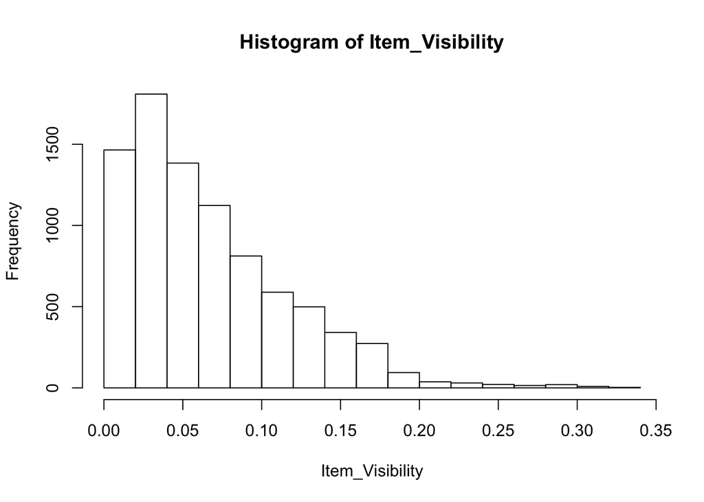

```r
hist(Item_Visibility)
```

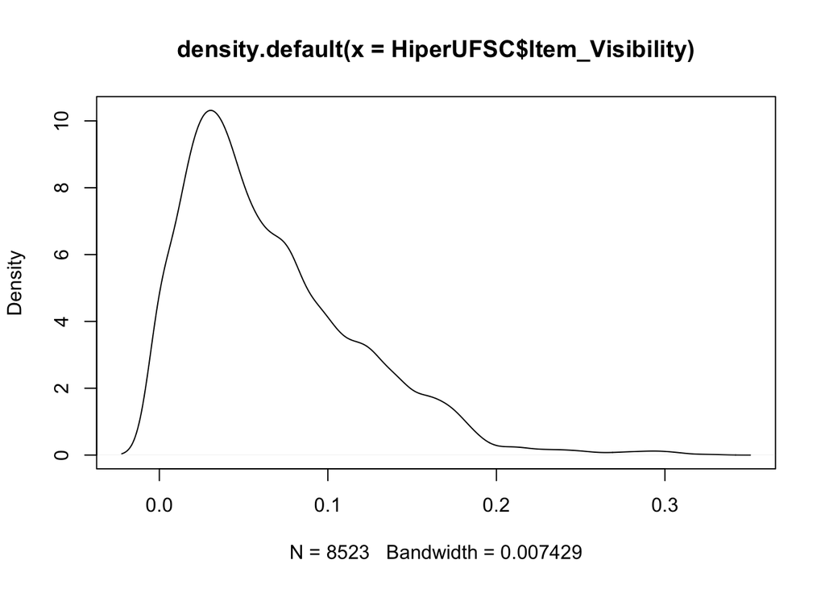

```r
plot(density(HiperUFSC$Item_Visibility))
```

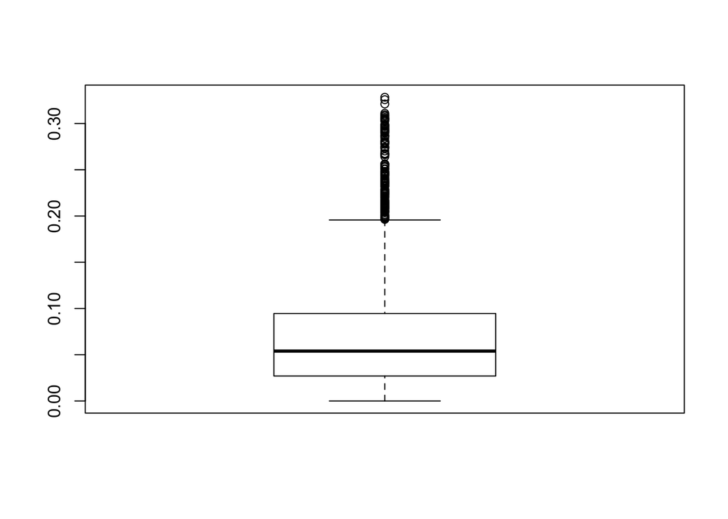

```r
boxplot(HiperUFSC$Item_Visibility)
```

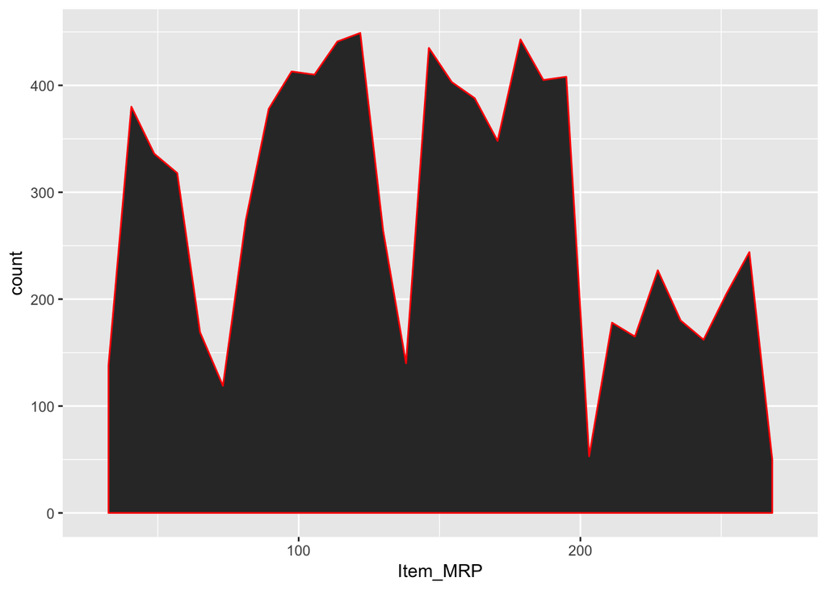

```r
c <- ggplot(HiperUFSC, aes(Item_MRP))
c + geom_area(stat = "bin", color ="red")
```

2. Categóricas

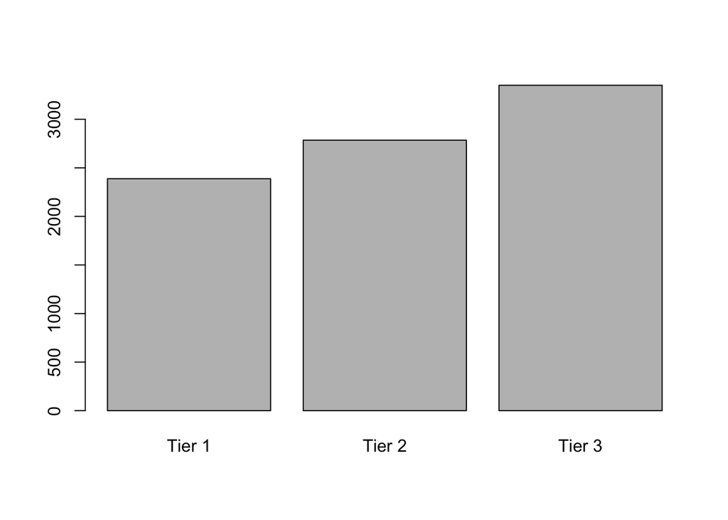

```r
plot(HiperUFSC$Outlet_Location_Type)
```

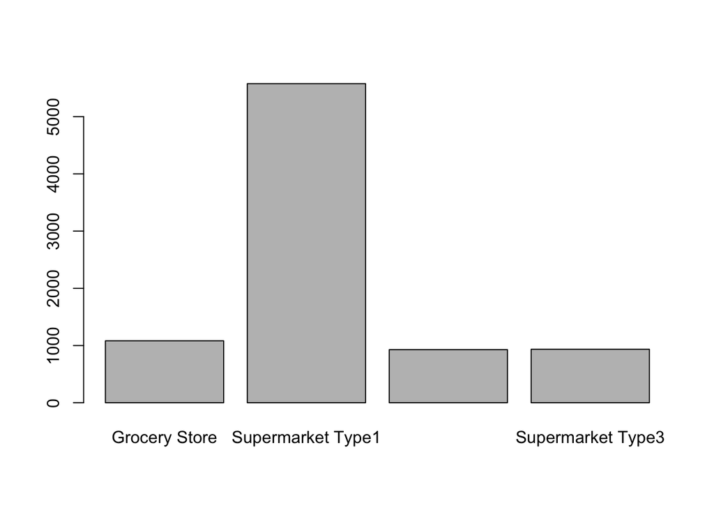

```r
plot(HiperUFSC$Outlet_Type)
```

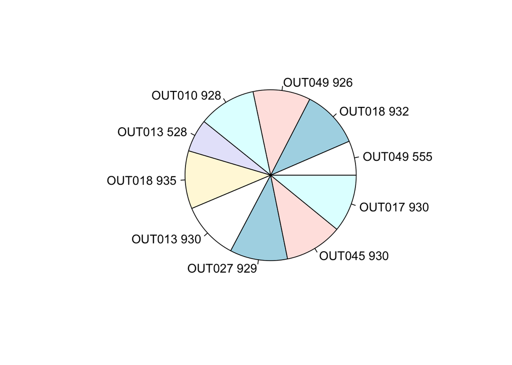

```r
dados = table(HiperUFSC$Outlet_Identifier)
legenda = paste(HiperUFSC$Outlet_Identifier, dados)
pie(dados, labels = legenda)
```

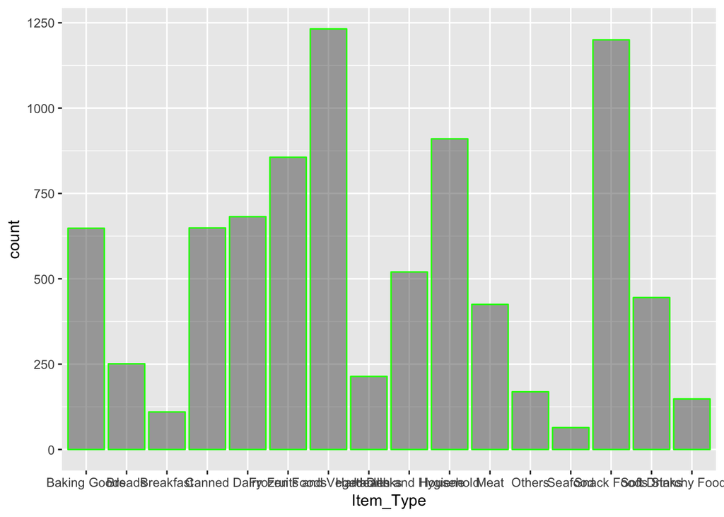

```r
d <- ggplot(HiperUFSC, aes(Item_Type))
d + geom_bar(color="green", alpha = 0.5)
```

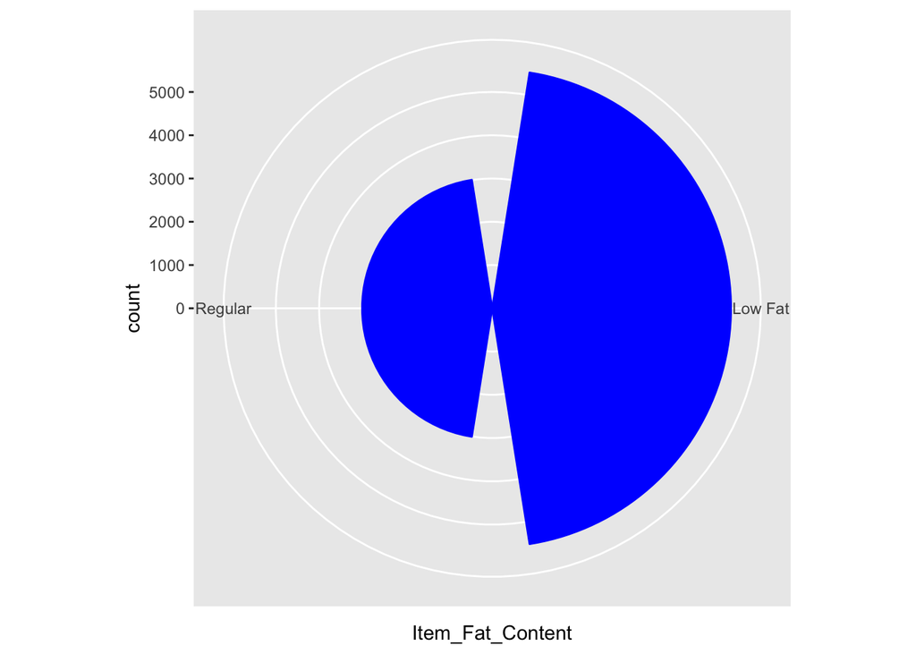

```r
ggplot(HiperUFSC, aes(Item_Fat_Content)) + geom_bar(color="blue", fill = "blue") + coord_polar(theta = "x", direction=1 )
```

Grupo 2: Gráficos envolvendo duas variáveis.

1. Quantitativa vs Quantitativa

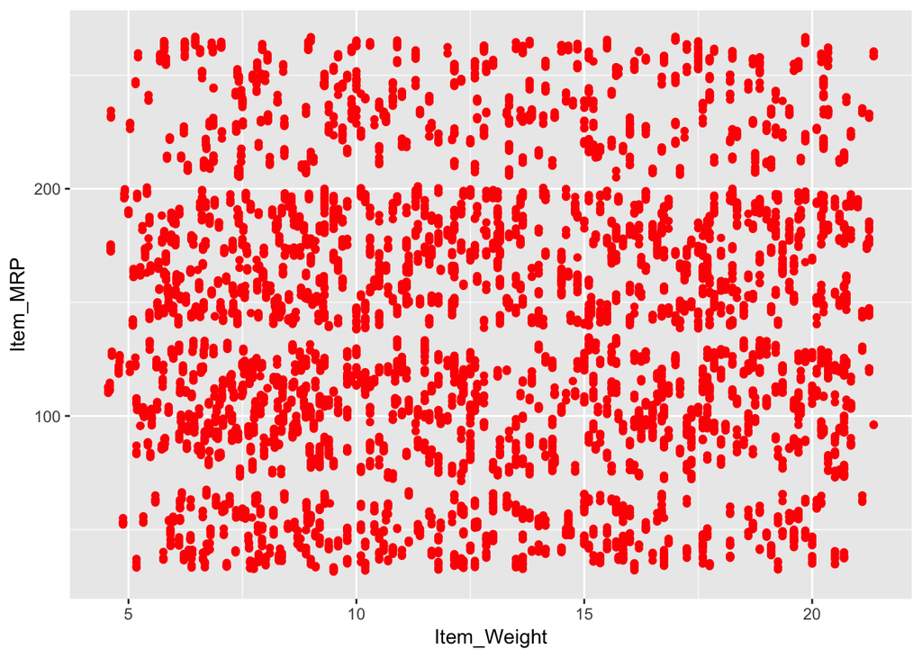

```r
e <- ggplot(HiperUFSC, aes(Item_Weight, Item_MRP))
e + geom_point(color = "red")
```

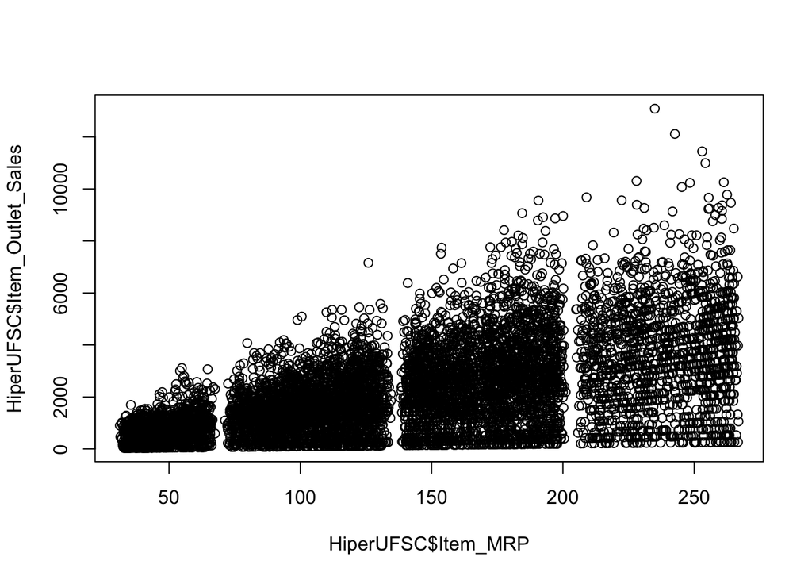

```r
plot(HiperUFSC$Item_MRP, HiperUFSC$Item_Outlet_Sales)
```

2. Categórica vs Categórica

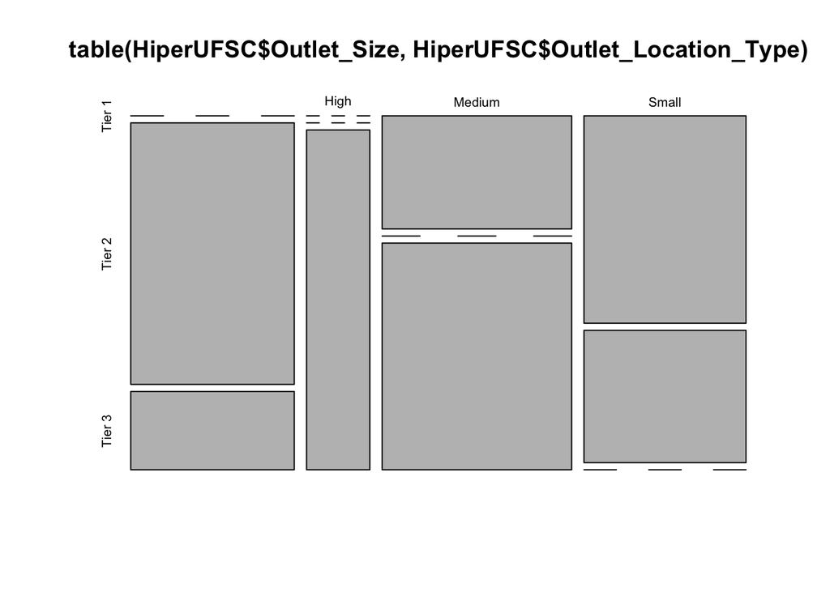

```r
plot(table(HiperUFSC$Outlet_Size, HiperUFSC$Outlet_Location_Type))
```

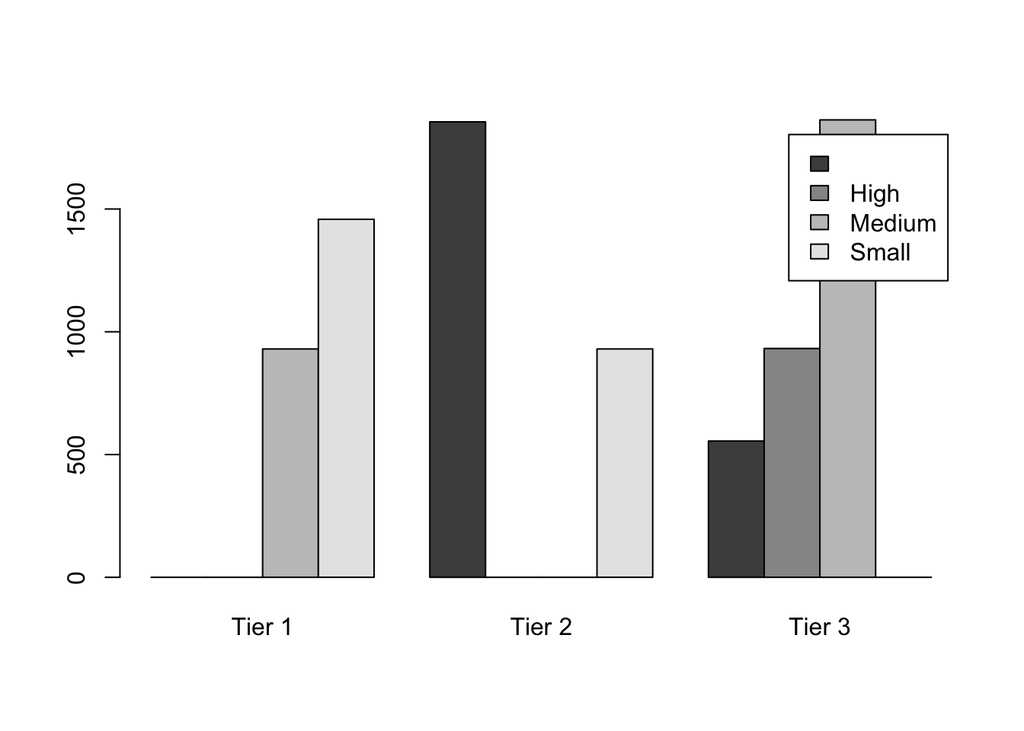

```r
bartable = table(HiperUFSC$Outlet_Size, HiperUFSC$Outlet_Location_Type)
barplot(bartable, beside = TRUE, legend = levels(unique(HiperUFSC$Outlet_Size)))
```

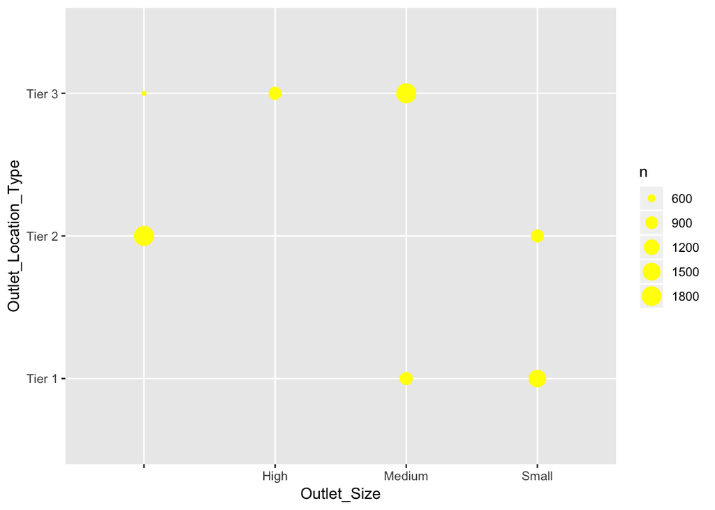

```r
g <- ggplot(HiperUFSC, aes(Outlet_Size, Outlet_Location_Type))
g + geom_count(color = "yellow", fill = "yellow")
```

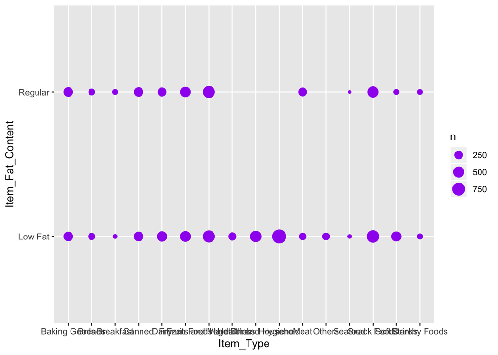

```r
h <- ggplot(HiperUFSC, aes(Item_Type, Item_Fat_Content))
h + geom_count(color = "purple", fill = "purple")
```

3. Categórica vs Quantitativa

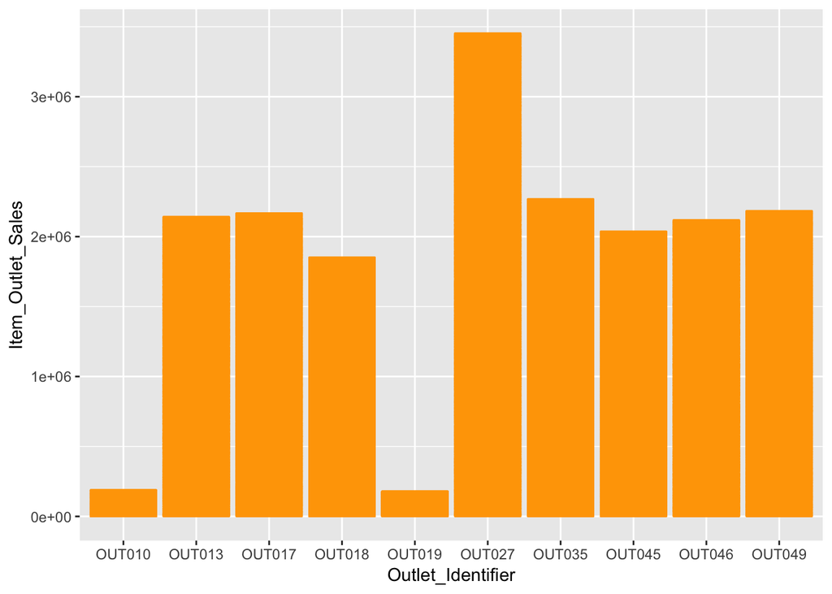

```r
f <- ggplot(HiperUFSC, aes(Outlet_Identifier, Item_Outlet_Sales))
f + geom_col(color="orange", fill="orange")
```

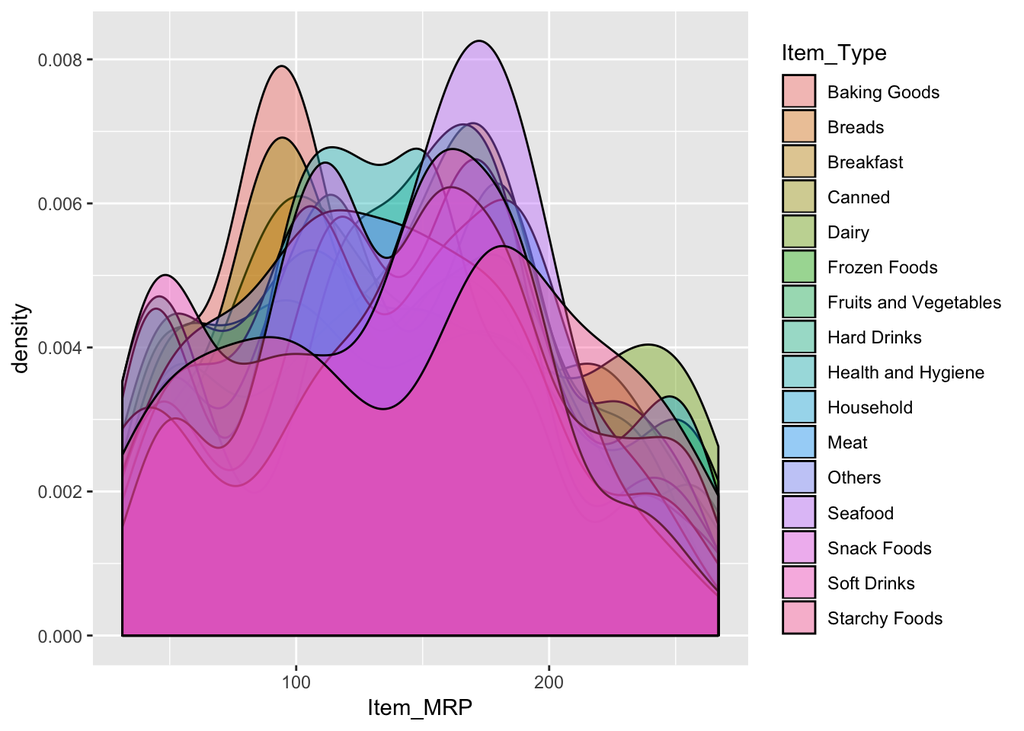

```r
c + geom_density(aes(fill = Item_Type), alpha = 0.4)
```

Grupo 3: Gráficos envolvendo múltiplas variáveis

2. Facets

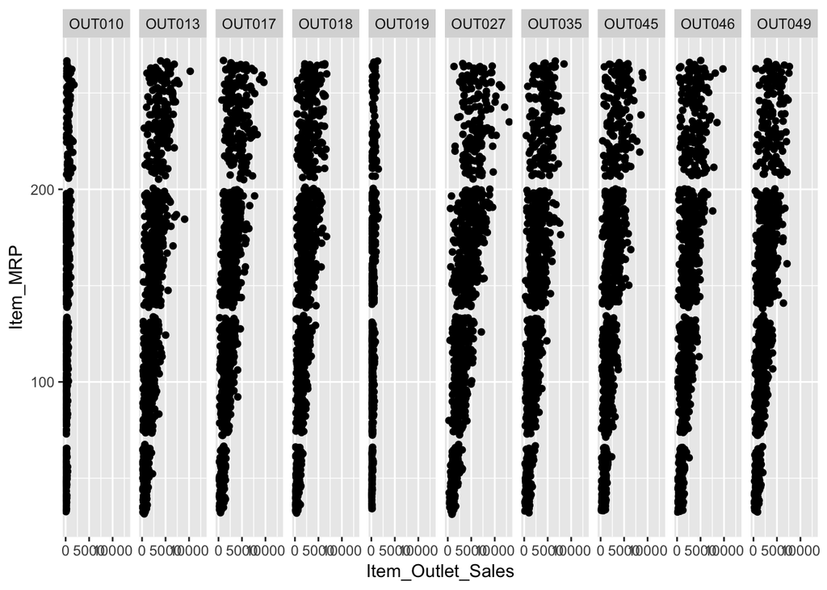

```r
t <- ggplot(HiperUFSC, aes(Item_Outlet_Sales, Item_MRP)) + geom_point()
t + facet_grid(. ~ Outlet_Identifier)
```